# Vyuziti teorie mnozin pri praci s daty

Ivan Petrusek, Jan Schubert

V tomto cviceni se zamerime na vyuziti teorie mnozim pri praci s daty. Probereme nasledujici zakladni operace:

- mohutnost mnoziny (pocet unikatnich prvku mnoziny)
- prunik dvou mnozin
- sjednoceni mnozin
- rozdil dvou mnozin

Tyto mnozinove operace jsou casto vyuzivany pri slucovani dat. Slucovani dat je velmi casta operace pri praci s daty. Dochazi k ni, pokud chceme spojit dve (nebo vice) datove matice z ruznych zdroju. Napriklad mame panelove setreni a potrebujeme spojit datove matice z vice vln. Panelova setreni jsou vyzkumy, ktere v case opakovane dotazuji stejne respondenty (dotazovani probiha v takzvanych vlnach). Kazdy respondent ma standardne napric datovymi soubory prirazeny jedinecny identifikator, na zaklade kterero se slouceni datovych matic realizuje. Dalsi priklad potreby slucovani dat muze nastat, kdyz mame data z mezinarodniho dotaznikoveho setreni (tzn. mame odpovedi od lidi z ruznych zemi) a do techto dat chceme nahrat hodnoty nejakych kontextualnich promennych (napr. miru nezamestnanosti v jednotlivych zemich v sledovanem obdobi.) V tomto pripade by jako identifikator pro slucovani poslouzilo jmeno zeme.

```r
df1 <- data.frame(id = 1:10,
                  vzdelani = factor(x = c(c(1, 2, 2, 3, 1),
                                          c(2, 3, 2, 3, 2)),
                                    ordered = TRUE,
                                    labels = c("zakladni", "stredoskolske", "vysokoskolske")),
                  vek = c(c(27, 49, 57, 45, 74),
                          c(45,51, 19, 59, 37)),
                  pohlavi = factor(rep(c(1,2), 5),
                                   ordered = FALSE,
                                   labels = c("muz", "zena")))

df2 <- data.frame(id = 6:14,
                  vzdelani = factor(x = c(c(2, 3, 2, 3, 2),
                                          c(3, 2, 1, 2)),
                                    ordered = TRUE,
                                    labels = c("zakladni", "stredoskolske", "vysokoskolske")),
                  vek = c(c(45,51, 19, 59, 37),
                          c(55, 41, 51, 18)),
                  deti = factor(c(1, 1, 0, 1, 0, 1, 1, 1, 0),
                                   ordered = FALSE,
                                   labels = c("ne", "ano")))
```

Prvni operace, kterou si ukazeme je mohutnost mnoziny. Mohutnost mnoziny vyjadruje pocet unikatnich (jedinecnych) prvku mnoziny. Pojdme se podivat, kolik unikatnich respondentu obsahuje `df1` a `df2`. Pokud chceme ukazat unikatni prvky nejake mnoziny (napriklad vektoru), muzeme k tomu pouzit funkci `unique`.

```r
unique(df1$id)
```

```
##  [1]  1  2  3  4  5  6  7  8  9 10
```

```r
unique(df2$id)
```

```
## [1]  6  7  8  9 10 11 12 13 14
```

Vidime, ze `df1` obsahuje 10 unikatnich respondentu a `df2` 9 unikatnich respondentu. Mohutnost mnoziny/vektoru `df1$id` je 10. Mohutnost mnoziny/vektoru `df2$id` je 9.

Ukazme si jeste mohutnost mnoziny na prikladu promenne (vektoru) vzdelani z obou datovych matic. Z hlediska teorie mnozin je mohutnost vlastne delka vektoru, ktery dostaneme volanim funkce unique. Vidime tedy, ze k urceni mohutnosti množiny kombinujeme funkce `unique` a `length`.

```r
length(unique(df1$vzdelani))
```

```
## [1] 3
```

```r
length(unique(df2$vzdelani))
```

```
## [1] 3
```

V obou mnozinach mame 3 unikatni hodnoty (`zakladni`, `stredoskolske` a `vysokoskolske`), obe mnoziny tedy maji mohutnost 3.

Pojdme se ted vratit k `id` respondentu. Jak jsme videli, `df1` obsahuje 10 unikatnich id a `df2` obsahuje 9 unikatnich id. Zaroven je ale zrejme, ze nektere id se vyskutuji v obou datovych maticich soucasne. Chceme zjisit, kolik unikatnich respondentu mame dohromady v obou datovych maticich. K tomu vyuzijeme sjednoceni mnozin, pro ktere je v `R` funkce `union`. Sjednocenim obou mnozin bude tedy mnozina, ktera obsahuje vsechny prvky (hodnoty promenne id), ktere jsou prvky alespon jedne z mnozin.

```r
sjednoceni <- union(df1$id, df2$id)
print(sjednoceni)
```

```
##  [1]  1  2  3  4  5  6  7  8  9 10 11 12 13 14
```

```r
print(paste0("pocet unikatnich respondentu: ", length(sjednoceni)))
```

```
## [1] "pocet unikatnich respondentu: 14"
```

Nebo muzeme vyuzit funkce, ktere uz zname: `c` a `unique`.

```r
sjednoceni2 <- unique(c(df1$id, df2$id))
print(sjednoceni2)
```

```
##  [1]  1  2  3  4  5  6  7  8  9 10 11 12 13 14
```

```r
sjednoceni == sjednoceni2
```

```
##  [1] TRUE TRUE TRUE TRUE TRUE TRUE TRUE TRUE TRUE TRUE TRUE TRUE TRUE TRUE
```

Ted jiz vime, kolik unikatnich respondentu mame v obou datovych maticich. Kolik respondentu mame soucasne v `df1` a v `df2`? Jinymi slovy, chceme identifikovat respondenty, kteri patri zaroven do obou mnozin. Zajimame se tedy o prunik obou mnozin, pro ktery je v `R` funkce `intersect`.

```r
prunik <- intersect(df1$id, df2$id)
print(prunik)
```

```
## [1]  6  7  8  9 10
```

```r
print(paste0("pocet respondentu vyskytujicih se v obou maticich: ", length(prunik)))
```

```
## [1] "pocet respondentu vyskytujicih se v obou maticich: 5"
```

Stejne tak muzeme pouzit k vypocteni pruniku mnozin pomoci logickych operaci. My jsme si ukazali, jak pouzivat relacni operatory `==` nebo `=!` k tomu, abychom zjistili jake prvky vektoru se rovnaji urcite hodnote. Pokud chceme porovnat prvky vektoru s vice nez jednou hodnotou (napriklad k dalsimu vektoru), pouzijeme k tomu operator `%in%`. Pokud bychom tedy chteli vedet, ktere prvky z datove matice `df1$id` jsou ve vektoru `df2$id`, tak toho muzeme dosahnout pomoci tohoto kodu.

```r
# vytvorime logicky vektoro velikosti vektoru df1$id
prunik2 <- df1$id %in% df2$id
# nyni muzeme pouzit vsechny logicke operace, ktere uz zname
# jako napr k indexovani hodnot
df1$id[prunik2]
```

```
## [1]  6  7  8  9 10
```

```r
# nebo ke zjisteni poctu shodnych prvku
sum(prunik2)
```

```
## [1] 5
```

Dalsi, co nas bude zajimat jsou respondenti, kteri jsou pouze v `df1` nebo pouze v `df2`. Tato operace odpovida rozdilu mnozin `df1$id` a `df2$id`. Rozdil mnozin muzeme v `R` zjistit pomoci funkce `setdiff`. U rozdilu mnozin zalezi na poradni jednotlivych mnozin. Tudiz je dulezite zvazit, o jaky rozdil se v konkretnim pripade zajimame.

```r
# respondenti pouze v df1
pouze_df1 <- setdiff(df1$id, df2$id)
print("Respondenti v df1 a ne df2:")
```

```
## [1] "Respondenti v df1 a ne df2:"
```

```r
print(pouze_df1)
```

```
## [1] 1 2 3 4 5
```

```r
# respondenti pouze v df2
pouze_df2 <- setdiff(df2$id, df1$id)
print("Respondenti v df2 a ne df1:")
```

```
## [1] "Respondenti v df2 a ne df1:"
```

```r
print(pouze_df2)
```

```
## [1] 11 12 13 14
```

```r
# Symetricky rozdil dvou mnozin = mnozina, ktera obsahuje vsechny prvky z obou mnozin, ktere nejsou v pruniku techto mnozin. Symetricky rozdil je tedy vlastne sjednoceni dvou rozdilu mnozin: df1$id - df2$id a df2$id - df1$id
symetricky_rozdil <- c(pouze_df1, pouze_df2)
print("Respondenti pouze v df1 nebo pouze v df2")
```

```
## [1] "Respondenti pouze v df1 nebo pouze v df2"
```

```r
print(symetricky_rozdil)
```

```
## [1]  1  2  3  4  5 11 12 13 14
```

```r
print(paste0("pocet respondentu pouze v df1 nebo pouze v df2: ", length(symetricky_rozdil)))
```

```
## [1] "pocet respondentu pouze v df1 nebo pouze v df2: 9"
```

Podobne opet muzeme pouzit operator `%in%`. Pokud potrebujeme zjistit, zda se prvky vektoru nerovnaji prvkum jineho vektoru, pridame pred dany vektor `!`.

```r
### respondenti pouze v df1
# vytvorime logicke vektory
pouze_df1_ <- !df1$id %in% df2$id
print("Respondenti v df1 a ne df2:")
```

```
## [1] "Respondenti v df1 a ne df2:"
```

```r
print(df1$id[pouze_df1_])
```

```
## [1] 1 2 3 4 5
```

```r
### respondenti pouze v df2
pouze_df2_ <- !df2$id %in% df1$id
print("Respondenti v df2 a ne df1:")
```

```
## [1] "Respondenti v df2 a ne df1:"
```

```r
print(df2$id[pouze_df2_])
```

```
## [1] 11 12 13 14
```

```r
# Symetricky rozdil dvou mnozin
symetricky_rozdil_ <- c(df1$id[pouze_df1_], df2$id[pouze_df2_])
print("Respondenti pouze v df1 nebo pouze v df2")
```

```
## [1] "Respondenti pouze v df1 nebo pouze v df2"
```

```r
print(symetricky_rozdil_)
```

```
## [1]  1  2  3  4  5 11 12 13 14
```

```r
print(paste0("pocet respondentu pouze v df1 nebo pouze v df2: ", length(symetricky_rozdil_)))
```

```
## [1] "pocet respondentu pouze v df1 nebo pouze v df2: 9"
```

Jak jsme zminili na zacatku. Tyto operace se pri praci s daty nejcasteji vyuzivaji pri slucovani/spojovani dat, tedy operaci kdy chceme sloucit dve datove matice. Ke spojovani dvou datovych matic se v `R` pouziva funkce `merge`. Pojdme se podivat na napovedu `?merge`. Jako prvni dva argumenty `x` a `y` pouzijeme datove matice, ktere chceme spojit. Dalsimi dulezitymi argumenty jsou `by`, pripadne `by.x` a `by.y`. V nich rekneme `R`, jake promenne (sloupce) z datovych matic ma pouzit na spojeni (to znamena, argument `by` definuje identifikacni promenne). Pokud maji oba sloupce stejne jmeno, muzeme pouzit argument `by`. Pokud maji sloupce, pres ktere budeme spojovat, jina jmena, specifikujeme jmeno sloupce z prvni datove matice v `by.x` a jmeno sloupce z druhe datove matice v `by.y`. Argumenty `all`, `all.x` a `all.y` pote specifikuji, jakym zpusobem chceme datove matice sloucit/spojit, tedy zda chceme prunik, sjednoceni nebo rozdil datovych matic.

Strategie spojovani zalezi na konkretni otazce, kterou chceme v nasi analyze zodpovedet. My si ukazeme nejcastejsi strategie, ktere odpovidaji operacim s mnozinami, jez jsme si ukazovali drive. Pokud nektera promenna existuje pouze v jedne datove matici (napriklad promenna `pohlavi` je pouze v `df1`), tak po slouceni datovych matic bude mit tato promenna u pripadu z druhe datove matice (`df2`) pouze chybejici hodnoty (`NA`). V nasledujicich prikladech pouzivame pro slucovani soucasne tri identifikacni promenne (`id`, `vzdelani` a `vek`). Tyto promenne se totiz nachazi soucasne v obou datovych maticich. Nize si vsimneme, ze po realizovani ruznych druhu slucovani (tzn. *full*, *inner*, *right*, *left*) ma sloucena datova matice vzdy 5 promennych. Obe puvodni datove matice (`df1` a `df2`) pritom mely 4 promenne.

**Sjednoceni**

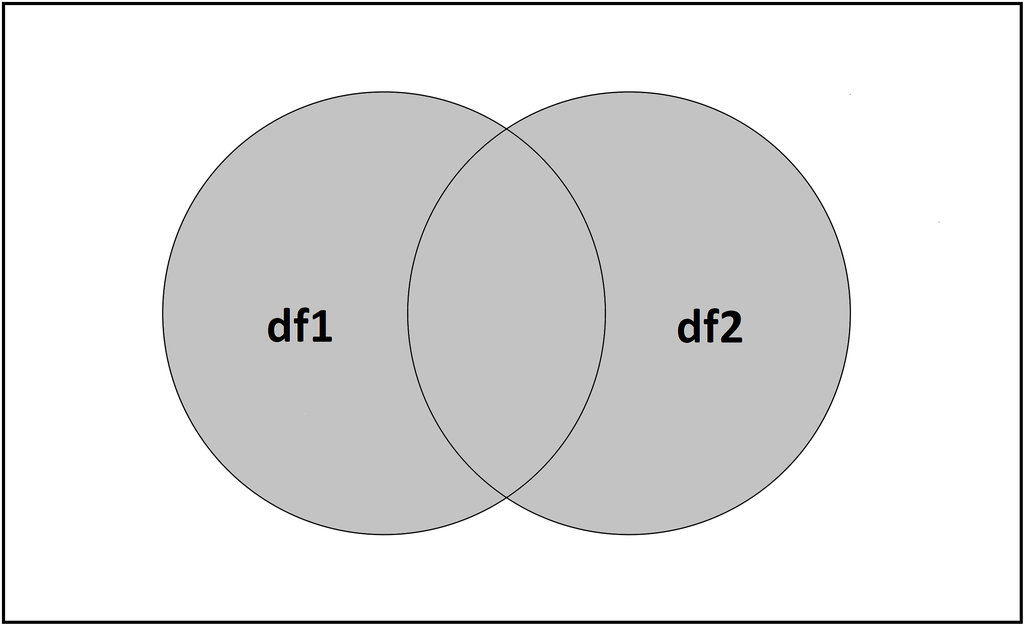

```r
# Sjednoceni mnozin
# z hlediska spojovani dat nazyvame tento druh slouceni dat: FULL JOIN (pozadujeme respondenty, kteri jsou alespon v jednom datovem souboru)
## union(df1$id, df2$id)
sjednoceni_df <- merge(x = df1, y = df2, by =  c("id", "vzdelani", "vek"), all.x = TRUE, all.y = TRUE)
print(sjednoceni_df)
```

```
##    id      vzdelani vek pohlavi deti
## 1   1      zakladni  27     muz <NA>
## 2   2 stredoskolske  49    zena <NA>
## 3   3 stredoskolske  57     muz <NA>
## 4   4 vysokoskolske  45    zena <NA>
## 5   5      zakladni  74     muz <NA>
## 6   6 stredoskolske  45    zena  ano
## 7   7 vysokoskolske  51     muz  ano
## 8   8 stredoskolske  19    zena   ne
## 9   9 vysokoskolske  59     muz  ano
## 10 10 stredoskolske  37    zena   ne
## 11 11 vysokoskolske  55    <NA>  ano
## 12 12 stredoskolske  41    <NA>  ano
## 13 13      zakladni  51    <NA>  ano
## 14 14 stredoskolske  18    <NA>   ne
```

```r
nrow(sjednoceni_df) == length(sjednoceni)
```

```
## [1] TRUE
```

**Prunik**

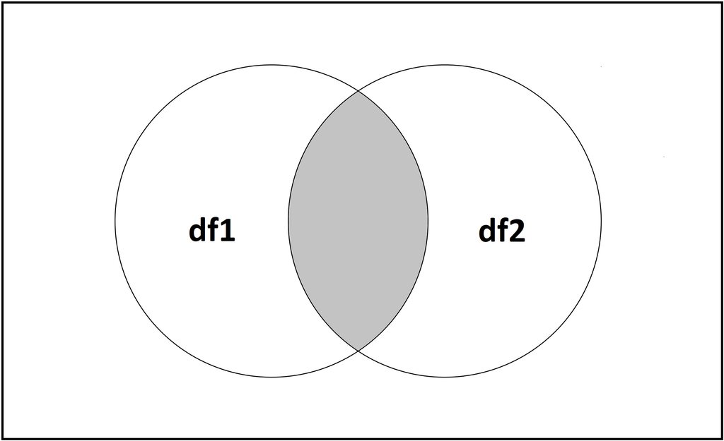

```r
# Prunik mnozin
# z hlediska spojovani dat nazyvame tento druh slouceni dat: INNER JOIN (pozadujeme pouze respodenty, kteri jsou soucasne v obou datovych souborech)
## intersect(df1$id, df2$id)
prunik_df <- merge(x = df1, y = df2, by =  c("id", "vzdelani", "vek"), all.x = FALSE, all.y = FALSE)
print(prunik_df)
```

```
##   id      vzdelani vek pohlavi deti
## 1 10 stredoskolske  37    zena   ne
## 2  6 stredoskolske  45    zena  ano
## 3  7 vysokoskolske  51     muz  ano
## 4  8 stredoskolske  19    zena   ne
## 5  9 vysokoskolske  59     muz  ano
```

```r
nrow(prunik_df) == length(prunik)
```

```
## [1] TRUE
```

**Rozdil df1 a df2 (df1 - df2)**

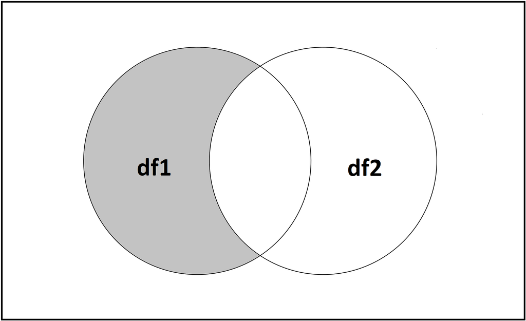

```r
# RIGHT JOIN (nasledujici spojeni dat pridava pozadovane hodnoty z matice vlevo (df1) do datove matice VPRAVO (df2))
# Pozadujeme tedy pouze respondenty, kteri jsou v matici df2 (all.y = TRUE) - vecnym cilem je, aby se do matice df2 nahraly dostupne hodnoty promenne pohlavi (z matice df1)
df2_ <- merge(x = df1, y = df2, by =  c("id", "vzdelani", "vek"), all.x = FALSE, all.y = TRUE)
print(df2_)
```

```
##   id      vzdelani vek pohlavi deti
## 1  6 stredoskolske  45    zena  ano
## 2  7 vysokoskolske  51     muz  ano
## 3  8 stredoskolske  19    zena   ne
## 4  9 vysokoskolske  59     muz  ano
## 5 10 stredoskolske  37    zena   ne
## 6 11 vysokoskolske  55    <NA>  ano
## 7 12 stredoskolske  41    <NA>  ano
## 8 13      zakladni  51    <NA>  ano
## 9 14 stredoskolske  18    <NA>   ne
```

```r
### Rozdil df1 a df2 (df1 - df2)
# potrebujeme vybrat ze sjednocene matice pouze ty pripady, ktere nejsou v df2_ (tzn. matici df2_ vytvorene v predchazejicim kroku prostrednictvim RIGHT JOIN)
pouze_df1_df <- sjednoceni_df[!sjednoceni_df$id %in% df2_$id, ]
print(pouze_df1_df)
```

```
##   id      vzdelani vek pohlavi deti
## 1  1      zakladni  27     muz <NA>
## 2  2 stredoskolske  49    zena <NA>
## 3  3 stredoskolske  57     muz <NA>
## 4  4 vysokoskolske  45    zena <NA>
## 5  5      zakladni  74     muz <NA>
```

```r
nrow(pouze_df1_df) == length(pouze_df1)
```

```
## [1] TRUE
```

**Rozdil df2 a df1 (df2 - df1)**

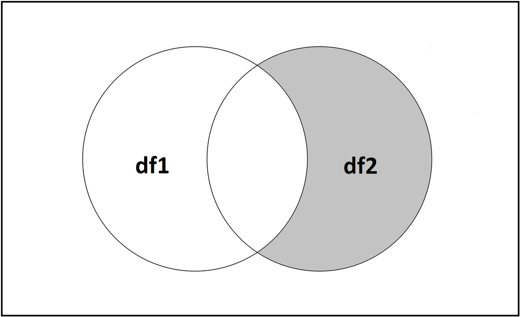

```r
# LEFT JOIN (nasledujici spojeni dat pridava pozadovane hodnoty z matice vpravo (df2) do datove matice VLEVO (df1))
# Pozadujeme tedy pouze respondenty, kteri jsou v matici df1 (all.x = TRUE) - cilem je, aby se do matice df1 nahraly dostupne hodnoty promenne deti (z matice df2)
df1_ <- merge(x = df1, y = df2, by =  c("id", "vzdelani", "vek"), all.x = TRUE, all.y = FALSE)
print(df1_)
```

```
##    id      vzdelani vek pohlavi deti
## 1   1      zakladni  27     muz <NA>
## 2   2 stredoskolske  49    zena <NA>
## 3   3 stredoskolske  57     muz <NA>
## 4   4 vysokoskolske  45    zena <NA>
## 5   5      zakladni  74     muz <NA>
## 6   6 stredoskolske  45    zena  ano
## 7   7 vysokoskolske  51     muz  ano
## 8   8 stredoskolske  19    zena   ne
## 9   9 vysokoskolske  59     muz  ano
## 10 10 stredoskolske  37    zena   ne
```

```r
### Rozdil df2 a df1 (df2 - df1)
# potrebujeme vybrat ze sjednocene matice pouze ty pripady, ktere nejsou v df1_ (tzn. matici df1_ vytvorene v predchazejicim kroku prostrednictvim LEFT JOIN)
pouze_df2_df <- sjednoceni_df[!sjednoceni_df$id %in% df1_$id, ]
print(pouze_df2_df)
```

```
##    id      vzdelani vek pohlavi deti
## 11 11 vysokoskolske  55    <NA>  ano
## 12 12 stredoskolske  41    <NA>  ano
## 13 13      zakladni  51    <NA>  ano
## 14 14 stredoskolske  18    <NA>   ne
```

```r
nrow(pouze_df2_df) == length(pouze_df2)
```

```
## [1] TRUE
```